# Untitled

J. Ignacio Lucas Lledó

12/2/2020

```r
library(ggplot2)
library(tidyr)
library(vcfR)
```

# Mapping results

```r
mapping1 <- read.table(params$MAPPING1, header=TRUE, sep='\t')
mapping1_long <- pivot_longer(mapping1[,-5], c(2,3,4), names_to='fate', values_to='reads')
mapping1_long$setting <- factor('very sensitive', levels=c('very sensitive', 'sensitive'))
```

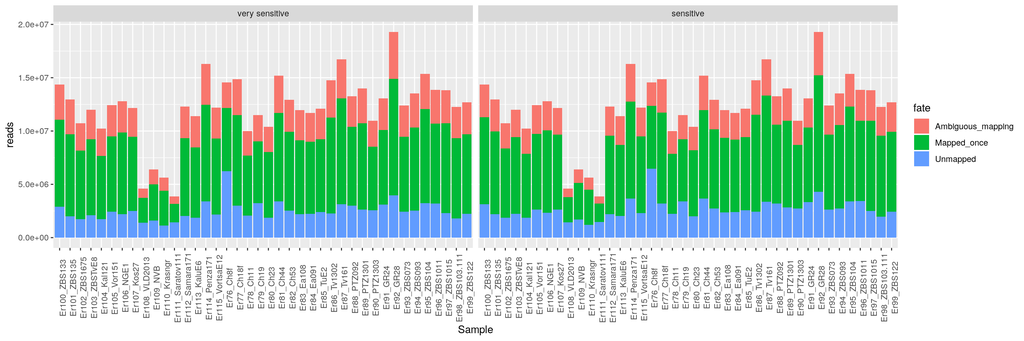

```r
mapping2 <- read.table(params$MAPPING2, header=TRUE, sep='\t')
mapping2_long <- pivot_longer(mapping2[,-5], c(2,3,4), names_to='fate', values_to='reads')
mapping2_long$setting <- factor('sensitive', levels=c('very_sensitive', 'sensitive'))

joined <- rbind(mapping1_long, mapping2_long)

ggplot(data=joined, mapping=aes(x=Sample, y=reads, fill=fate)) +
   geom_bar(stat='identity') +
   theme(axis.text.x = element_text(angle=90)) +
   facet_wrap(~setting)
```

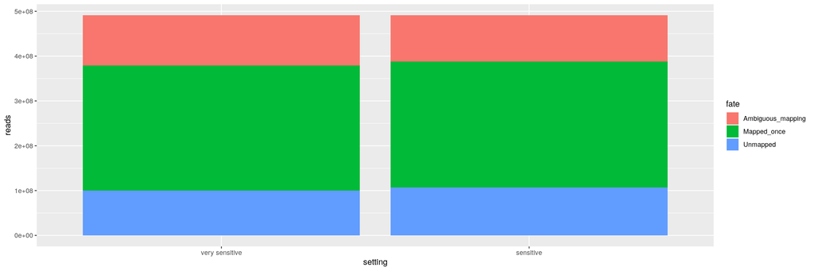

```r
ggplot(data=joined, mapping=aes(x=setting, y=reads, fill=fate)) +
   geom_bar(stat='identity')
```

The global proportion of reads mapped once is 0.5676579 in the very sensitive mapping and 0.5705607 in the just sensitive mapping. Not a big difference.

# Filtering of variant sites

The other concern is the filtering of variant sites, which I think is quite critical. The vcf files contain information on global depth (across samples), which is important. It would be a good chance to learn the usage of vcfR. But after trying a bit, I find it slow and difficult to extract the depth information. I’d rather use `gawk` to get depth information, which is what I need now. Now, how do I use a variable in the R namespace (`params$VCF1`) inside a `gawk` chunk? Apparently, I can pass arguments to gawk through the chunk’s options [https://github.com/yihui/knitr-examples/blob/master/024-engine-awk.Rmd]. But I could not make that run. I resort to the `README.sh`, where I get the tables I need, and then use R to plot results, as in the old times.

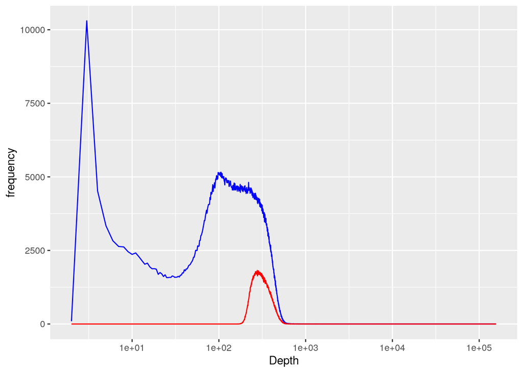

```r
TotalDepth <- read.table('total_depth.txt', col.names=c('DP','original', 'filtered'))
ggplot(data=TotalDepth, mapping=aes(x=DP)) +
   scale_x_log10() +
   geom_line(aes(y=original), color='blue') +
   geom_line(aes(y=filtered), color='red') +
   xlab('Depth') + ylab('frequency')
```

The shape of the distribution of total depths in the filtered vcf looks fine. The most remarkable issue may be the magnitude of data loss during filtering. Vcftools does not allow to filter by total depth, but only by individual sample’s depth. The limits used were 4 and 200 per sample, and a minimum of 75% of the 40 samples should be present. Thus, theoretical whole depth limits were 120 and 8000. The actual minimum and maximum depth values observed in the filtered vcf file are 160 and 6548.

It is possible that we are wasting data by the sample-specific maximum depth. I would trust most sites where total depth is below 1000, even if some samples are over 200. I would like to quantify that. For that, I need individual sample’s depth data, now available in file `all_depths.txt`.

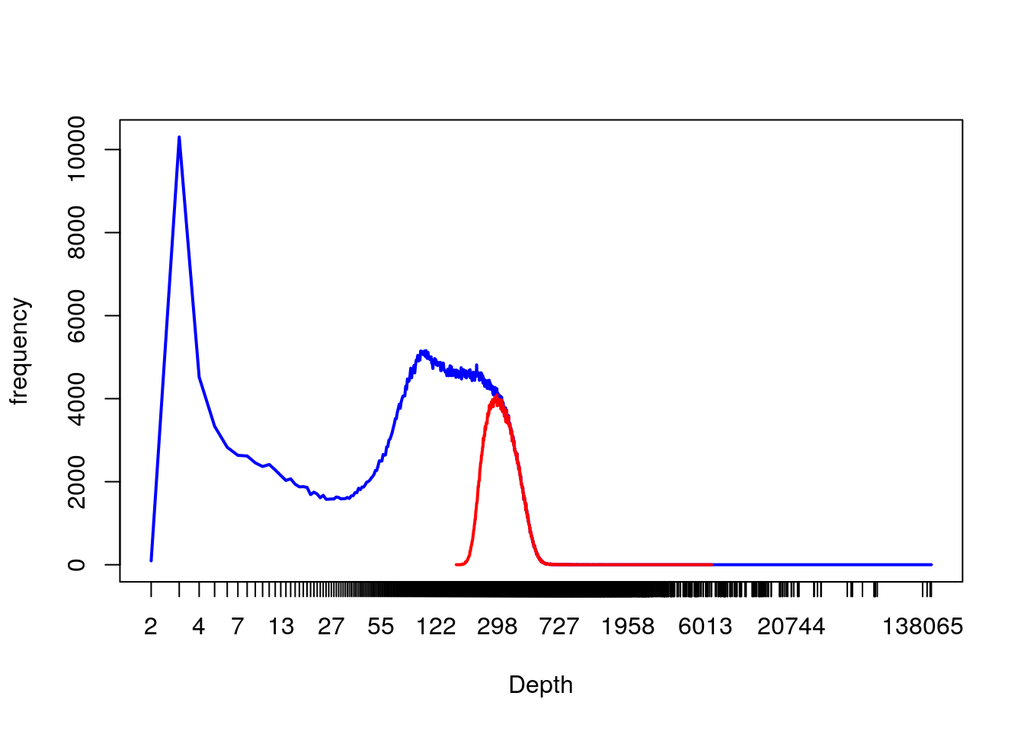

```r
depths <- read.table('all_depths.txt', header=TRUE)
# Sites with at least 30 samples with depths between 4 and 200:
min4max200 <- rowSums(depths[,2:41] >= 4 & depths[,2:41] <= 200) >= 30
plot(table(depths[,1]), log='x', type='l', col='blue', xlab='Depth', ylab='frequency')
points(table(depths[min4max200,1]), col='red', type='l')
```

The maximum depth allowed per sample of 200 is doing a good job at keeping most sites with a reasonable coverage, without admitting too many of the excessively covered ones. We loose sites on the low coverage end, which could only be helped by lowering the minimum coverage allowed per sample, or relaxing the percentage of samples required to be covered (75% currently). None of these options seem a good idea.

In the dataset from central European contact zone, population assignment was clear, because very few hybrids were present. There, we were able to use species- specific quotas (e.g., at least 10 *E. europaeus* and 10 *E. roumanicus* samples covered per site), which optimizes the selection of sites. But we cannot do the same when hybridization seems much more frequent.

The difference in height of the filtered sites (in red) between the two plots indicates we loose many sites from analysis for reasons other than the coverage. The filtering step requires also a minimum allele frequency of 0.01, a maximum allele frequency of 0.95, neither more nor less than 2 alleles, a minimum quality of 50 and a spacing of at least 261 nucleotides between SNPs. I would not change any of those parameters, but perhaps the maximum allele frequency. With 40 samples, the precision in allele frequency is 0.0125. I think allele frequency limits should be symmetrical, like 0.0125 and 0.9875, in order to admit singleton alleles of both types, reference and alternative.

```r
save(joined, TotalDepth, depths, file='assessment.RData')
```